# Shelter Animal Outcomes

# 3 Modeling and Interpretation

In this section, we present what algorithm is used, why are we using it and how it is used. The objective is to build the final submission file containing the probabilities for each outcome type of each animal given in the test set.

Extreme Gradient Boosting Trees is a good choice to modelize our data. Each tree is a decision tree representing a group of animals where the probabilities of each outcome are approximately the same. For example, first level could be if the animal is sterile, intact or unknown. The second level could be if an animal has a name or not.

## 3.1 Fine Tuning Parameters

We prepare the parameters and matrices for the cross-validation and final prediction. Since we need to get the probabilities for each class, then the objective used is `multi:softprob`. This metric requires the number of classes `num_class` to predict which is 5 in our case. We have found that the evaluation metric used is the multi-class log loss function which is `mlogloss` for the `XGBoost` algorithm.

We use the `subsample` parameter which is the subsample ratio of the training instances. The parameter `eta` control the learning rate since the XGBoost uses the gradient descent which needs a learning rate parameter.

```r
outcomes.string <- sort(unique(train$OutcomeType))
outcome.type <- CategoryToInteger(train$OutcomeType) - 1
indices <- order(unique(train$OutcomeType))

train$OutcomeSubtype <- NULL
train$OutcomeType <- NULL

outcome.class.num <- length(outcomes.string)
param <- list(objective        = "multi:softprob",
              num_class        = outcome.class.num,
              eta              = 0.12,      # Control the learning rate
              subsample        = 0.8,
              max_depth        = 8,        # Maximum depth of the tree
              colsample_bytree = 0.9,     # Subsample ratio of columns when constructing each tree
              eval_metric      = "mlogloss")
```

## 3.2 Cross-Validation

For each tree, we will have the average of 10 error estimates to obtain a more robust estimate of the true prediction error. This is done for all trees and we get the optimal number of trees to use for the test set.

We also display 2 curves indicating the test and train multi-Logloss mean progression. The vertical dotted line is the optimal number of trees. This plot shows if the model overfit or underfit.

http://stats.stackexchange.com/questions/103459/how-do-i-know-which-method-of-cross-validation-is-best

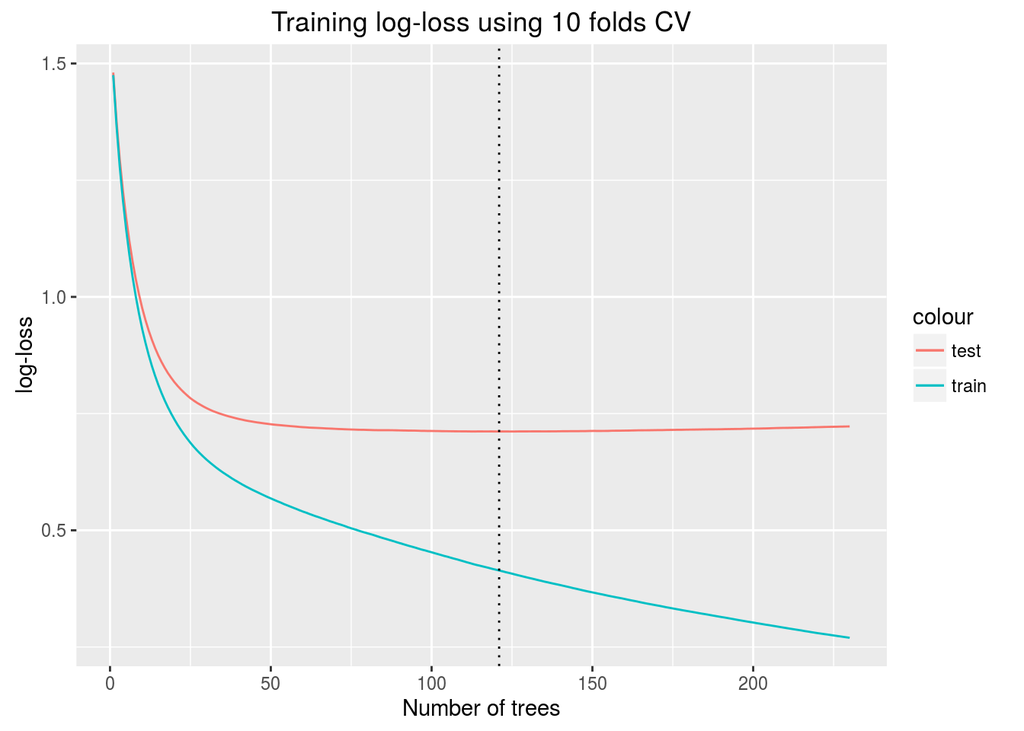

```
##      train.mlogloss.mean train.mlogloss.std test.mlogloss.mean
##   1:            1.475111           0.003918           1.480649
##   2:            1.368849           0.003043           1.379403
##   3:            1.280670           0.002463           1.296582
##   4:            1.207875           0.003879           1.228346
##   5:            1.145335           0.005523           1.170455
##  ---
## 226:            0.273856           0.002023           0.721984
## 227:            0.272875           0.002011           0.722153
## 228:            0.271873           0.002015           0.722307
## 229:            0.270858           0.001929           0.722459
## 230:            0.269838           0.001999           0.722582
##      test.mlogloss.std names
##   1:          0.004783     1
##   2:          0.004409     2
##   3:          0.004844     3
##   4:          0.005615     4
##   5:          0.006325     5
##  ---
## 226:          0.019219   226
## 227:          0.019200   227
## 228:          0.019143   228
## 229:          0.019240   229
## 230:          0.019318   230
```

```
##
## Optimal testing set Log-Loss score: 0.711664
```

```
##
## Associated training set Log-Loss score: 0.41399
```

```
##
## Interval testing set Log-Loss score: [ 0.695175 ,  0.728153 ].
```

```
##
## Difference between optimal training and testing sets Log-Loss: 0.297674
```

```
##
## Optimal number of trees: 121
```